# MTA Ridership Final Project

J.Kimbrough, Kennedy Rodriguez

2025-05-01

```r
url <- "https://data.ny.gov/api/views/vxuj-8kew/rows.csv?accessType=DOWNLOAD"
mta_data_raw <- read_csv(url)
view(mta_data_raw)
glimpse(mta_data_raw)
```

```
## Rows: 1,776
## Columns: 15
## $ Date                                                      <chr> "01/01/2021"…
## $ `Subways: Total Estimated Ridership`                      <dbl> 613692, 1027…
## $ `Subways: % of Comparable Pre-Pandemic Day`               <dbl> 0.29, 0.38, …
## $ `Buses: Total Estimated Ridership`                        <dbl> 378288, 3508…
## $ `Buses: % of Comparable Pre-Pandemic Day`                 <dbl> 0.41, 0.29, …
## $ `LIRR: Total Estimated Ridership`                         <dbl> 28977, 33980…
## $ `LIRR: % of Comparable Pre-Pandemic Day`                  <dbl> 0.35, 0.35, …
## $ `Metro-North: Total Estimated Ridership`                  <dbl> 14988, 30341…
## $ `Metro-North: % of Comparable Pre-Pandemic Day`           <dbl> 0.17, 0.23, …
## $ `Access-A-Ride: Total Scheduled Trips`                    <dbl> 5960, 4904, …
## $ `Access-A-Ride: % of Comparable Pre-Pandemic Day`         <dbl> 0.44, 0.34, …
## $ `Bridges and Tunnels: Total Traffic`                      <dbl> 445950, 4985…
## $ `Bridges and Tunnels: % of Comparable Pre-Pandemic Day`   <dbl> 0.65, 0.65, …
## $ `Staten Island Railway: Total Estimated Ridership`        <dbl> 805, 1262, 1…
## $ `Staten Island Railway: % of Comparable Pre-Pandemic Day` <dbl> 0.29, 0.31, …
```

# —- Cleaning Data —–

```r
anyNA(mta_data_raw)
```

```
## [1] FALSE
```

```r
any(sapply(mta_data_raw, function(x) any(x=="")))
```

```
## [1] FALSE
```

```r
any(sapply(mta_data_raw, function(x) any(x == -999)))
```

```
## [1] FALSE
```

```r
df <- mta_data_raw %>%
  mutate(Date = mdy(Date)) %>%
  mutate(across(where(is.character), ~ na_if(., "missing"))) %>%
  mutate(across(where(is.numeric), ~ na_if(., -999))) %>%
  mutate(across(where(is.character), ~ na_if(., ""))) %>%
  na.omit()

head(df)
```

```
## # A tibble: 6 × 15
##   Date       `Subways: Total Estimated Ridership` Subways: % of Comparable Pre…¹
##   <date>                                    <dbl>                          <dbl>
## 1 2021-01-01                               613692                           0.29
## 2 2022-01-01                              1027918                           0.38
## 3 2023-01-01                              1675507                           0.8
## 4 2024-01-01                              1648734                           0.79
## 5 2025-01-01                              1779352                           0.85
## 6 2021-01-02                               988418                           0.37
## # ℹ abbreviated name: ¹`Subways: % of Comparable Pre-Pandemic Day`
## # ℹ 12 more variables: `Buses: Total Estimated Ridership` <dbl>,
## #   `Buses: % of Comparable Pre-Pandemic Day` <dbl>,
## #   `LIRR: Total Estimated Ridership` <dbl>,
## #   `LIRR: % of Comparable Pre-Pandemic Day` <dbl>,
## #   `Metro-North: Total Estimated Ridership` <dbl>,
## #   `Metro-North: % of Comparable Pre-Pandemic Day` <dbl>, …
```

# — Exploratory Data Analysis —

```r
colnames(df)
```

```
##  [1] "Date"
##  [2] "Subways: Total Estimated Ridership"
##  [3] "Subways: % of Comparable Pre-Pandemic Day"
##  [4] "Buses: Total Estimated Ridership"
##  [5] "Buses: % of Comparable Pre-Pandemic Day"
##  [6] "LIRR: Total Estimated Ridership"
##  [7] "LIRR: % of Comparable Pre-Pandemic Day"
##  [8] "Metro-North: Total Estimated Ridership"
##  [9] "Metro-North: % of Comparable Pre-Pandemic Day"
## [10] "Access-A-Ride: Total Scheduled Trips"
## [11] "Access-A-Ride: % of Comparable Pre-Pandemic Day"
## [12] "Bridges and Tunnels: Total Traffic"
## [13] "Bridges and Tunnels: % of Comparable Pre-Pandemic Day"
## [14] "Staten Island Railway: Total Estimated Ridership"
## [15] "Staten Island Railway: % of Comparable Pre-Pandemic Day"
```

# Histograms

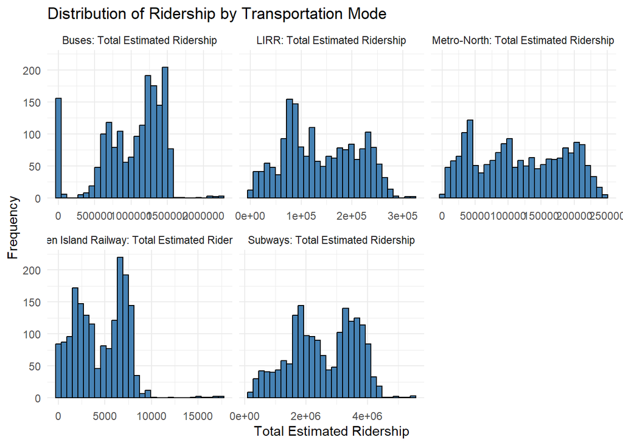

```r
df_long <- df %>%
   dplyr::select(`Subways: Total Estimated Ridership`,
         `Buses: Total Estimated Ridership`,
         `LIRR: Total Estimated Ridership`,
         `Metro-North: Total Estimated Ridership`,
         `Staten Island Railway: Total Estimated Ridership`) %>%
  pivot_longer(cols = everything(),
               names_to = "Transportation_Mode",
               values_to = "Ridership")

ggplot(df_long, aes(x = Ridership)) +
  geom_histogram(bins = 30, fill = "steelblue", color = "black") +
  facet_wrap(~ Transportation_Mode, scales = "free_x") +
  labs(title = "Distribution of Ridership by Transportation Mode",
       x = "Total Estimated Ridership",
       y = "Frequency") +
  theme_minimal()
```

# Plotted Relationships

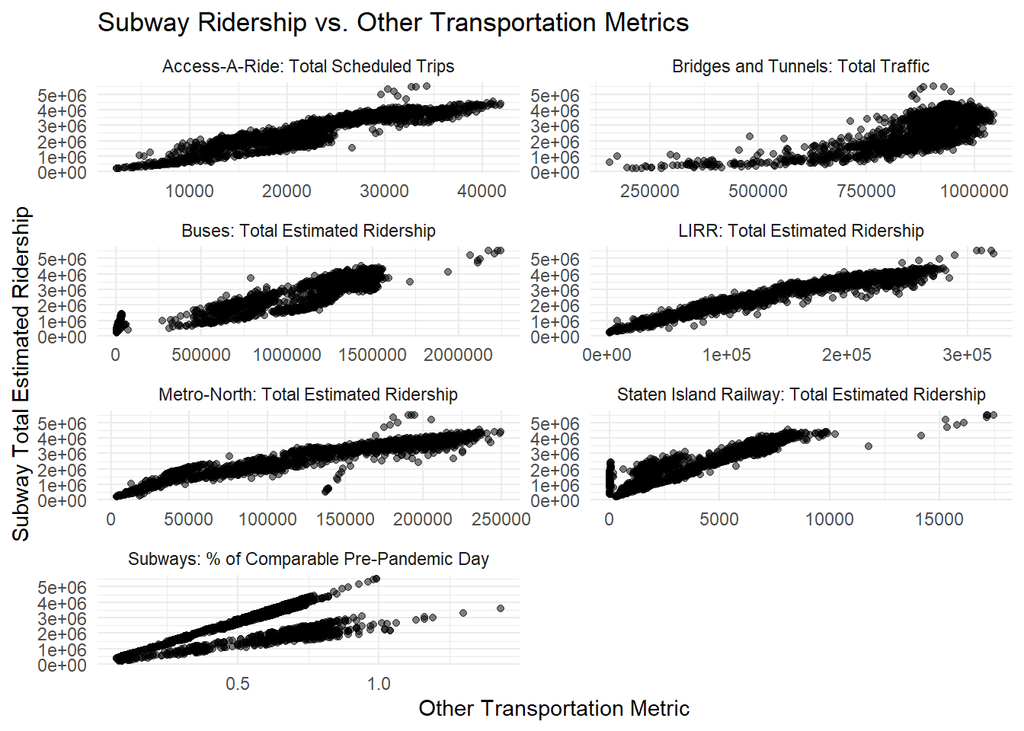

```r
df_long <- df %>%
   dplyr::select(
    `Subways: % of Comparable Pre-Pandemic Day`,
    `Buses: Total Estimated Ridership`,
    `LIRR: Total Estimated Ridership`,
    `Metro-North: Total Estimated Ridership`,
    `Access-A-Ride: Total Scheduled Trips`,
    `Bridges and Tunnels: Total Traffic`,
    `Staten Island Railway: Total Estimated Ridership`,
    `Subways: Total Estimated Ridership`
  ) %>%
  pivot_longer(
    cols = -`Subways: Total Estimated Ridership`,
    names_to = "Other_Metric",
    values_to = "Other_Value"
  )

ggplot(df_long, aes(x = Other_Value, y = `Subways: Total Estimated Ridership`)) +
  geom_point(alpha = 0.5) +
  facet_wrap(~ Other_Metric, scales = "free", ncol = 2) + # Removed the extra + before the comment
  labs(
    title = "Subway Ridership vs. Other Transportation Metrics",
    x = "Other Transportation Metric",
    y = "Subway Total Estimated Ridership"
  ) +
  theme_minimal()
```

# Correlations

```r
numeric_cols <- names(df)[sapply(df, is.numeric) & names(df) != "Subways: Total Estimated Ridership"]

correlation_results <- df %>%
  dplyr::select(-Date) %>% # Ensure Date is removed
  pivot_longer(
    cols = all_of(numeric_cols),
    names_to = "Other_Metric",
    values_to = "Other_Value"
  ) %>%
  group_by(Other_Metric) %>%
  summarize(
    correlation = cor(`Subways: Total Estimated Ridership`, Other_Value, use = "pairwise.complete.obs")
  )

print(correlation_results)
```

```
## # A tibble: 13 × 2
##    Other_Metric                                            correlation
##    <chr>                                                         <dbl>
##  1 Access-A-Ride: % of Comparable Pre-Pandemic Day               0.706
##  2 Access-A-Ride: Total Scheduled Trips                          0.909
##  3 Bridges and Tunnels: % of Comparable Pre-Pandemic Day         0.659
##  4 Bridges and Tunnels: Total Traffic                            0.738
##  5 Buses: % of Comparable Pre-Pandemic Day                       0.640
##  6 Buses: Total Estimated Ridership                              0.884
##  7 LIRR: % of Comparable Pre-Pandemic Day                        0.409
##  8 LIRR: Total Estimated Ridership                               0.961
##  9 Metro-North: % of Comparable Pre-Pandemic Day                 0.601
## 10 Metro-North: Total Estimated Ridership                        0.943
## 11 Staten Island Railway: % of Comparable Pre-Pandemic Day       0.469
## 12 Staten Island Railway: Total Estimated Ridership              0.923
## 13 Subways: % of Comparable Pre-Pandemic Day                     0.646
```

```r
"Buses: Total Estimated Ridership
The correlation coefficient between bus ridership and subway ridership is 0.88, indicating a strong positive correlation. This suggests that when more people ride the bus, subway ridership tends to be higher as well. The two systems may serve as complements or be influenced by similar demand patterns.

Buses: % of Comparable Pre-Pandemic Day
The correlation here is 0.64, showing a moderate positive relationship. As bus ridership returns to its pre-pandemic baseline, subway ridership also tends to increase, though not as strongly as with total bus numbers.

LIRR: Total Estimated Ridership
With a very high correlation of 0.96, this represents a very strong positive relationship. It indicates that Long Island Rail Road ridership is highly synchronized with subway usage, likely due to intermodal transfers and similar commuter patterns.

LIRR: % of Comparable Pre-Pandemic Day
The correlation is 0.41, which is weakly positive. This suggests that while total LIRR ridership is strongly associated with subway use, the pace of recovery relative to pre-pandemic levels is not as tightly linked.

Metro-North: Total Estimated Ridership
The coefficient is 0.94, indicating another very strong positive correlation. Like the LIRR, Metro-North ridership appears to rise and fall in tandem with subway ridership.

Metro-North: % of Comparable Pre-Pandemic Day
This yields a moderate positive correlation of 0.60. Similar to LIRR trends, total ridership aligns more closely with subway usage than the relative recovery percentage does.

Access-A-Ride: Total Scheduled Trips
A correlation of 0.91 suggests a strong positive relationship. This implies that when more paratransit trips are scheduled, subway ridership also increases, possibly reflecting broader patterns of urban mobility and accessibility.

Access-A-Ride: % of Comparable Pre-Pandemic Day
The coefficient is 0.71, still a moderately strong correlation. As Access-A-Ride approaches pre-pandemic service levels, subway usage tends to rise, though again with less intensity than total trip counts.

Bridges and Tunnels: Total Traffic
The correlation of 0.74 shows a moderate positive relationship between road traffic and subway ridership. This may reflect general increases in overall mobility within the region.

Bridges and Tunnels: % of Comparable Pre-Pandemic Day
At 0.66, this remains a moderate positive correlation, implying that as bridge and tunnel traffic returns to normal, subway ridership also tends to rise.

Staten Island Railway: Total Estimated Ridership
This yields a strong positive correlation of 0.92. Subway and Staten Island Railway usage appear closely linked, likely due to the ferry and rail connections to the main subway system.

Staten Island Railway: % of Comparable Pre-Pandemic Day
The correlation is 0.47, which is weak but positive. Again, while absolute ridership levels align well, the recovery pace doesn't strongly predict subway usage.

Summary
Overall, total ridership figures for other transportation modes tend to have stronger correlations with subway usage than their percentages of pre-pandemic levels. This suggests that actual volume of riders is a more reliable indicator of subway demand than recovery benchmarks alone. Commuter rail lines (LIRR and Metro-North) and Access-A-Ride show particularly high associations with subway usage, pointing to potential interdependencies in how New Yorkers use different MTA services."
```

```
## [1] "Buses: Total Estimated Ridership\nThe correlation coefficient between bus ridership and subway ridership is 0.88, indicating a strong positive correlation. This suggests that when more people ride the bus, subway ridership tends to be higher as well. The two systems may serve as complements …
```

# Data Summary Table

```r
df_with_year <- df %>%
  mutate(Year = year(Date))

ridership_summary <- df_with_year %>%
  group_by(Year) %>%
  summarize(
    Total_Subway_Ridership = sum(`Subways: Total Estimated Ridership`, na.rm = TRUE),
    Total_Bus_Ridership = sum(`Buses: Total Estimated Ridership`, na.rm = TRUE),
    Total_LIRR_Ridership = sum(`LIRR: Total Estimated Ridership`, na.rm = TRUE),
    Total_MNR_Ridership = sum(`Metro-North: Total Estimated Ridership`, na.rm = TRUE),
    Total_SIR_Ridership = sum(`Staten Island Railway: Total Estimated Ridership`, na.rm = TRUE),
    Total_AAR_Ridership =sum(`Access-A-Ride: Total Scheduled Trips`, na.rm = TRUE),
  ) %>%
  filter(Year != 2025)


print(ridership_summary)
```

```
## # A tibble: 5 × 7
##    Year Total_Subway_Ridership Total_Bus_Ridership Total_LIRR_Ridership
##   <dbl>                  <dbl>               <dbl>                <dbl>
## 1  2020              370096769           147387699             17816724
## 2  2021              759810246           381637866             35269817
## 3  2022             1012505879           423946824             51998770
## 4  2023             1150217108           425539799             64882573
## 5  2024             1194201712           408872440             74848660
## # ℹ 3 more variables: Total_MNR_Ridership <dbl>, Total_SIR_Ridership <dbl>,
## #   Total_AAR_Ridership <dbl>
```

# Regression Question

## Updated - What type of regression model best predicts total daily subway ridership?

## — Multiple Linear Regression —

```r
# Subways: Total Estimated Ridership

full_model <- lm(`Subways: Total Estimated Ridership` ~ ., data = df)

summary(full_model)
```

```
##
## Call:
## lm(formula = `Subways: Total Estimated Ridership` ~ ., data = df)
##
## Residuals:
##     Min      1Q  Median      3Q     Max
## -370472  -47635    2301   54610  373079
##
## Coefficients:
##                                                             Estimate Std. Error
## (Intercept)                                               -6.109e+05  2.492e+05
## Date                                                       3.061e+01  1.363e+01
## `Subways: % of Comparable Pre-Pandemic Day`                3.309e+06  5.087e+04
## `Buses: Total Estimated Ridership`                         7.759e-01  2.803e-02
## `Buses: % of Comparable Pre-Pandemic Day`                 -1.224e+06  5.404e+04
## `LIRR: Total Estimated Ridership`                         -1.688e+00  2.628e-01
## `LIRR: % of Comparable Pre-Pandemic Day`                   4.378e+05  4.342e+04
## `Metro-North: Total Estimated Ridership`                   7.565e+00  2.454e-01
## `Metro-North: % of Comparable Pre-Pandemic Day`           -1.441e+06  5.306e+04
## `Access-A-Ride: Total Scheduled Trips`                     3.334e+01  1.510e+00
## `Access-A-Ride: % of Comparable Pre-Pandemic Day`         -7.891e+05  3.667e+04
## `Bridges and Tunnels: Total Traffic`                       2.647e-01  5.123e-02
## `Bridges and Tunnels: % of Comparable Pre-Pandemic Day`   -1.043e+05  5.211e+04
## `Staten Island Railway: Total Estimated Ridership`         7.646e+01  4.686e+00
## `Staten Island Railway: % of Comparable Pre-Pandemic Day` -2.511e+05  2.626e+04
##                                                           t value Pr(>|t|)
## (Intercept)                                                -2.451   0.0143 *
## Date                                                        2.246   0.0249 *
## `Subways: % of Comparable Pre-Pandemic Day`                65.055  < 2e-16 ***
## `Buses: Total Estimated Ridership`                         27.676  < 2e-16 ***
## `Buses: % of Comparable Pre-Pandemic Day`                 -22.644  < 2e-16 ***
## `LIRR: Total Estimated Ridership`                          -6.424 1.70e-10 ***
## `LIRR: % of Comparable Pre-Pandemic Day`                   10.084  < 2e-16 ***
## `Metro-North: Total Estimated Ridership`                   30.823  < 2e-16 ***
## `Metro-North: % of Comparable Pre-Pandemic Day`           -27.162  < 2e-16 ***
## `Access-A-Ride: Total Scheduled Trips`                     22.082  < 2e-16 ***
## `Access-A-Ride: % of Comparable Pre-Pandemic Day`         -21.517  < 2e-16 ***
## `Bridges and Tunnels: Total Traffic`                        5.167 2.65e-07 ***
## `Bridges and Tunnels: % of Comparable Pre-Pandemic Day`    -2.001   0.0456 *
## `Staten Island Railway: Total Estimated Ridership`         16.316  < 2e-16 ***
## `Staten Island Railway: % of Comparable Pre-Pandemic Day`  -9.563  < 2e-16 ***
## ---
## Signif. codes:  0 '***' 0.001 '**' 0.01 '*' 0.05 '.' 0.1 ' ' 1
##
## Residual standard error: 79240 on 1761 degrees of freedom
## Multiple R-squared:  0.9945, Adjusted R-squared:  0.9945
## F-statistic: 2.289e+04 on 14 and 1761 DF,  p-value: < 2.2e-16
```

### The model explains about 99.45% of the variability in subway ridership, which is extremely high. With an F-stat of 22,890 and a p-value < 2.2e-16, the overall model is highly statistically significant.

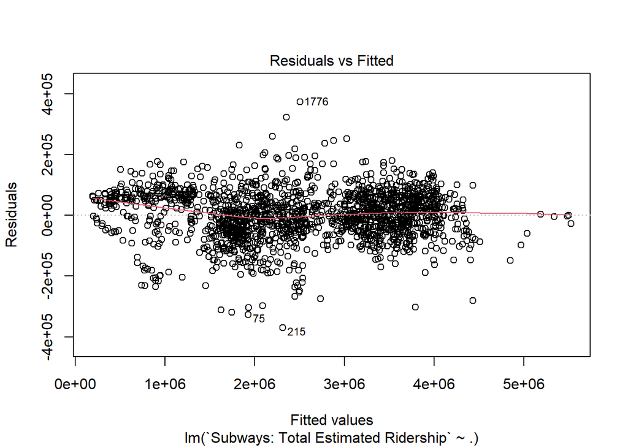

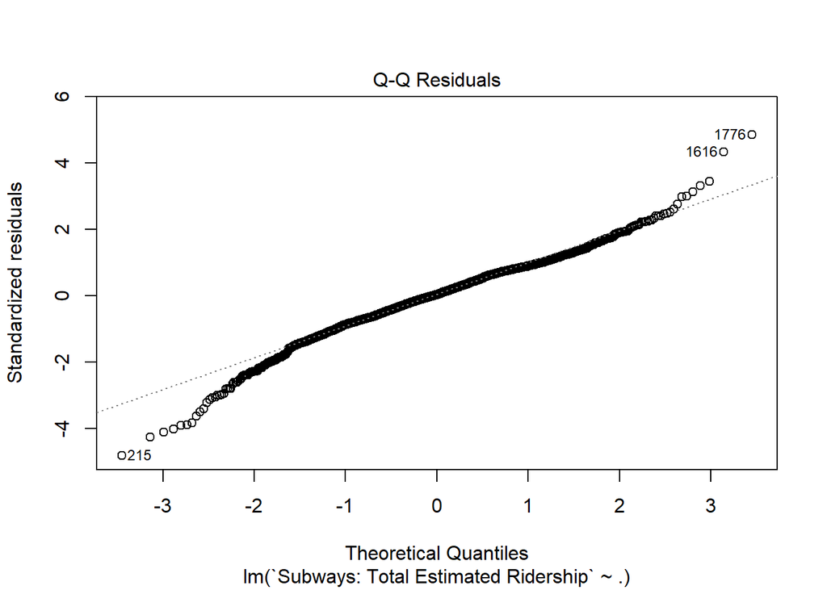

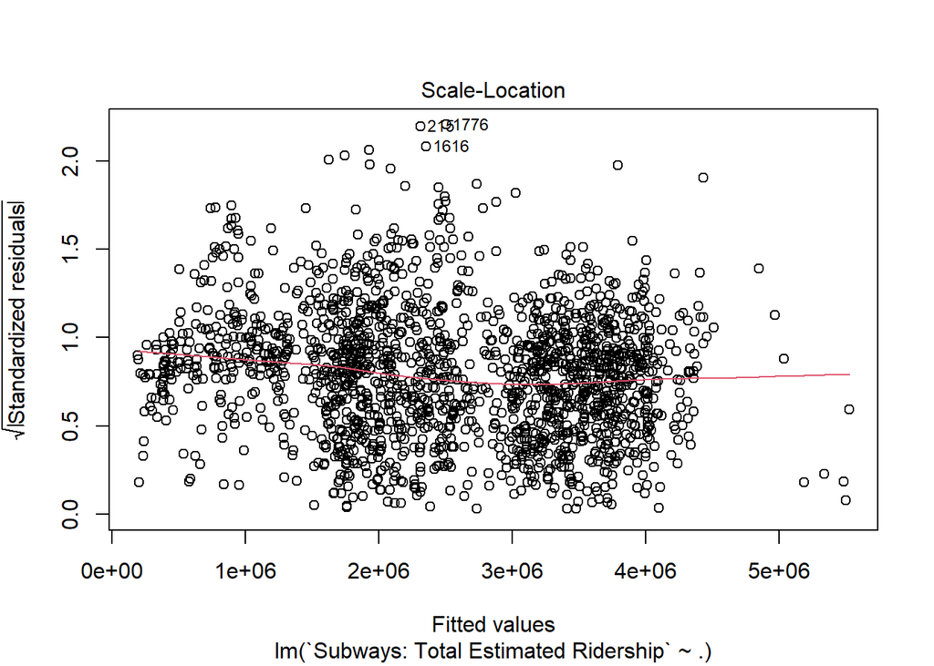

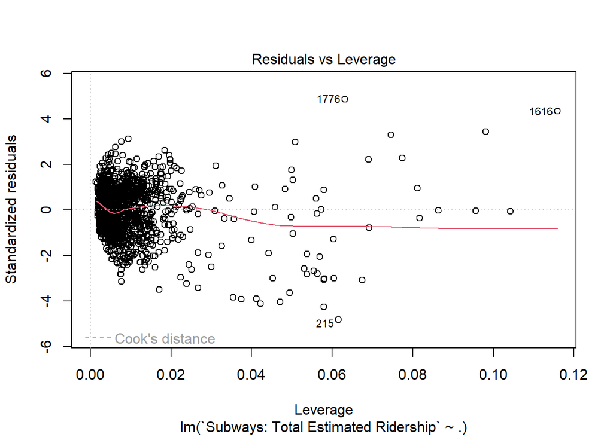

```r
plot(full_model)
```

```r
#NO Date, Bridges and Tunnels: % of Comparable Pre-Pandemic Day
reduced_model <- lm(`Subways: Total Estimated Ridership` ~ . -Date -`Bridges and Tunnels: % of Comparable Pre-Pandemic Day`, data = df)
summary(reduced_model)
```

```
##
## Call:
## lm(formula = `Subways: Total Estimated Ridership` ~ . - Date -
##     `Bridges and Tunnels: % of Comparable Pre-Pandemic Day`,
##     data = df)
##
## Residuals:
##     Min      1Q  Median      3Q     Max
## -379122  -46918    3771   54886  354444
##
## Coefficients:
##                                                             Estimate Std. Error
## (Intercept)                                               -6.092e+04  1.483e+04
## `Subways: % of Comparable Pre-Pandemic Day`                3.323e+06  4.814e+04
## `Buses: Total Estimated Ridership`                         8.052e-01  2.586e-02
## `Buses: % of Comparable Pre-Pandemic Day`                 -1.292e+06  4.777e+04
## `LIRR: Total Estimated Ridership`                         -1.542e+00  2.526e-01
## `LIRR: % of Comparable Pre-Pandemic Day`                   4.359e+05  4.271e+04
## `Metro-North: Total Estimated Ridership`                   7.665e+00  2.414e-01
## `Metro-North: % of Comparable Pre-Pandemic Day`           -1.435e+06  5.236e+04
## `Access-A-Ride: Total Scheduled Trips`                     3.329e+01  1.507e+00
## `Access-A-Ride: % of Comparable Pre-Pandemic Day`         -7.673e+05  3.536e+04
## `Bridges and Tunnels: Total Traffic`                       1.603e-01  2.503e-02
## `Staten Island Railway: Total Estimated Ridership`         7.027e+01  3.947e+00
## `Staten Island Railway: % of Comparable Pre-Pandemic Day` -2.360e+05  2.565e+04
##                                                           t value Pr(>|t|)
## (Intercept)                                                -4.108 4.17e-05 ***
## `Subways: % of Comparable Pre-Pandemic Day`                69.024  < 2e-16 ***
## `Buses: Total Estimated Ridership`                         31.140  < 2e-16 ***
## `Buses: % of Comparable Pre-Pandemic Day`                 -27.044  < 2e-16 ***
## `LIRR: Total Estimated Ridership`                          -6.107 1.25e-09 ***
## `LIRR: % of Comparable Pre-Pandemic Day`                   10.206  < 2e-16 ***
## `Metro-North: Total Estimated Ridership`                   31.754  < 2e-16 ***
## `Metro-North: % of Comparable Pre-Pandemic Day`           -27.405  < 2e-16 ***
## `Access-A-Ride: Total Scheduled Trips`                     22.093  < 2e-16 ***
## `Access-A-Ride: % of Comparable Pre-Pandemic Day`         -21.698  < 2e-16 ***
## `Bridges and Tunnels: Total Traffic`                        6.402 1.96e-10 ***
## `Staten Island Railway: Total Estimated Ridership`         17.802  < 2e-16 ***
## `Staten Island Railway: % of Comparable Pre-Pandemic Day`  -9.200  < 2e-16 ***
## ---
## Signif. codes:  0 '***' 0.001 '**' 0.01 '*' 0.05 '.' 0.1 ' ' 1
##
## Residual standard error: 79350 on 1763 degrees of freedom
## Multiple R-squared:  0.9945, Adjusted R-squared:  0.9945
## F-statistic: 2.663e+04 on 12 and 1763 DF,  p-value: < 2.2e-16
```

### This model still explains about 99.45% of the variability in subway ridership, which is extremely high. The F-stat is still pretty high at 26,630 and a low p-value. The overall model is still statistically significant.

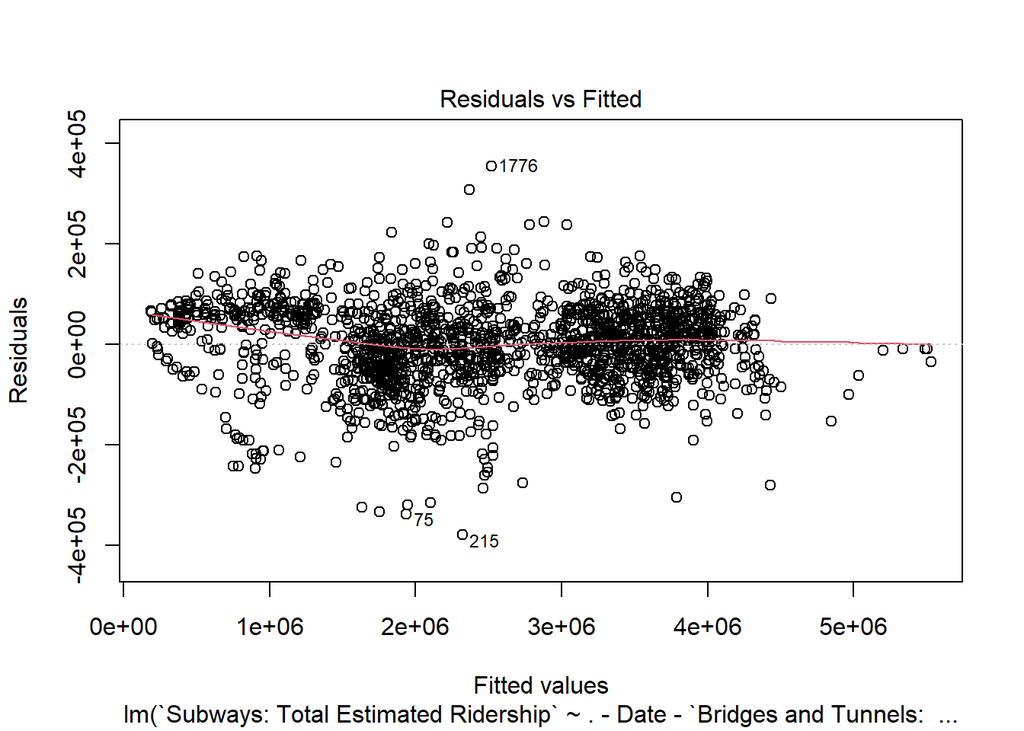

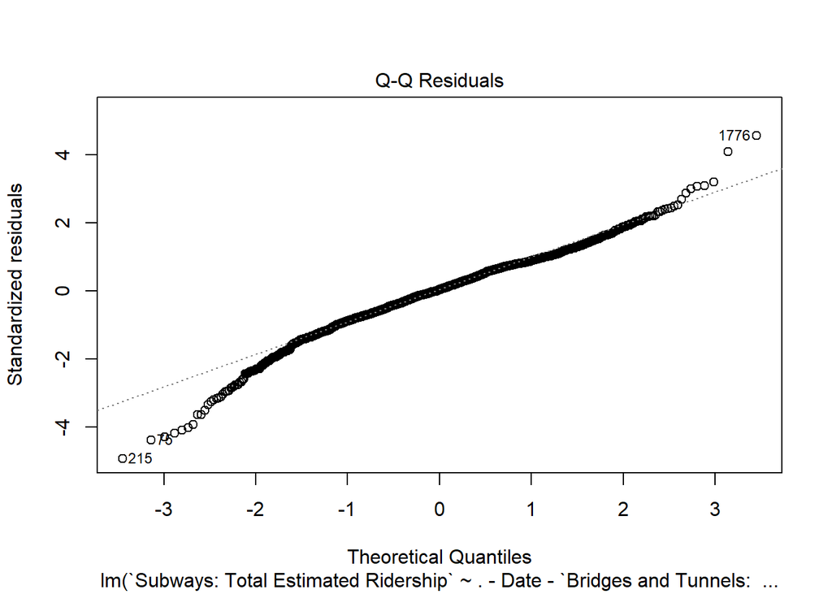

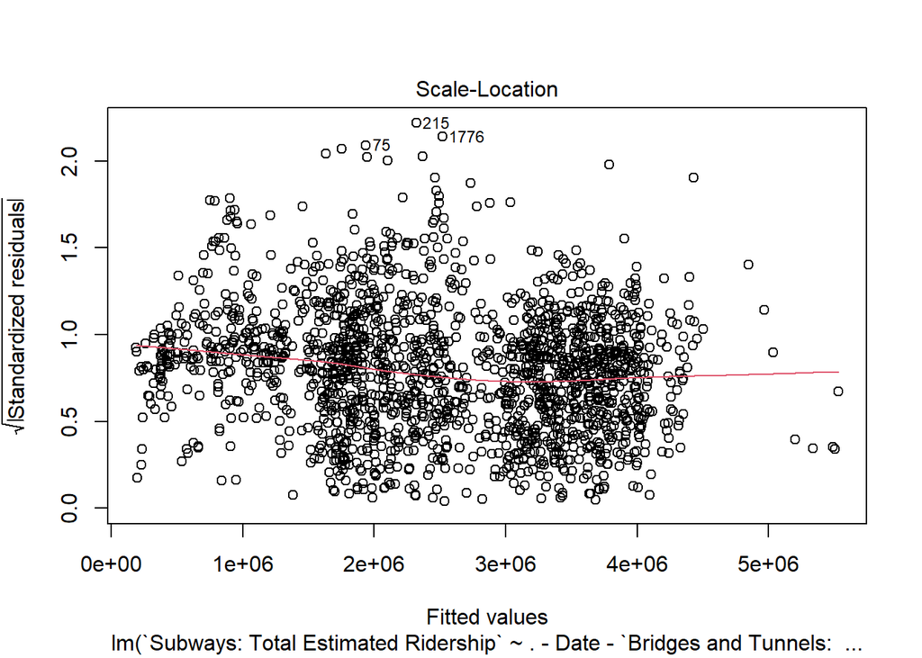

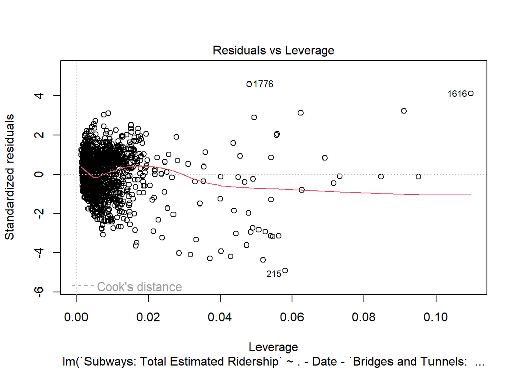

```r
plot(reduced_model)
```

```r
reduced_model_step <- step(reduced_model)
```

```
## Start:  AIC=40085.44
## `Subways: Total Estimated Ridership` ~ (Date + `Subways: % of Comparable Pre-Pandemic Day` +
##     `Buses: Total Estimated Ridership` + `Buses: % of Comparable Pre-Pandemic Day` +
##     `LIRR: Total Estimated Ridership` + `LIRR: % of Comparable Pre-Pandemic Day` +
##     `Metro-North: Total Estimated Ridership` + `Metro-North: % of Comparable Pre-Pandemic Day` +
##     `Access-A-Ride: Total Scheduled Trips` + `Access-A-Ride: % of Comparable Pre-Pandemic Day` +
##     `Bridges and Tunnels: Total Traffic` + `Bridges and Tunnels: % of Comparable Pre-Pandemic Day` +
##     `Staten Island Railway: Total Estimated Ridership` + `Staten Island Railway: % of Comparable Pre-Pandemic Day`) -
##     Date - `Bridges and Tunnels: % of Comparable Pre-Pandemic Day`
##
##                                                             Df  Sum of Sq
## <none>
## - `LIRR: Total Estimated Ridership`                          1 2.3481e+11
## - `Bridges and Tunnels: Total Traffic`                       1 2.5809e+11
## - `Staten Island Railway: % of Comparable Pre-Pandemic Day`  1 5.3301e+11
## - `LIRR: % of Comparable Pre-Pandemic Day`                   1 6.5589e+11
## - `Staten Island Railway: Total Estimated Ridership`         1 1.9957e+12
## - `Access-A-Ride: % of Comparable Pre-Pandemic Day`          1 2.9646e+12
## - `Access-A-Ride: Total Scheduled Trips`                     1 3.0736e+12
## - `Buses: % of Comparable Pre-Pandemic Day`                  1 4.6055e+12
## - `Metro-North: % of Comparable Pre-Pandemic Day`            1 4.7293e+12
## - `Buses: Total Estimated Ridership`                         1 6.1063e+12
## - `Metro-North: Total Estimated Ridership`                   1 6.3492e+12
## - `Subways: % of Comparable Pre-Pandemic Day`                1 3.0001e+13
##                                                                    RSS   AIC
## <none>                                                      1.1102e+13 40085
## - `LIRR: Total Estimated Ridership`                         1.1336e+13 40121
## - `Bridges and Tunnels: Total Traffic`                      1.1360e+13 40124
## - `Staten Island Railway: % of Comparable Pre-Pandemic Day` 1.1635e+13 40167
## - `LIRR: % of Comparable Pre-Pandemic Day`                  1.1757e+13 40185
## - `Staten Island Railway: Total Estimated Ridership`        1.3097e+13 40377
## - `Access-A-Ride: % of Comparable Pre-Pandemic Day`         1.4066e+13 40504
## - `Access-A-Ride: Total Scheduled Trips`                    1.4175e+13 40517
## - `Buses: % of Comparable Pre-Pandemic Day`                 1.5707e+13 40700
## - `Metro-North: % of Comparable Pre-Pandemic Day`           1.5831e+13 40714
## - `Buses: Total Estimated Ridership`                        1.7208e+13 40862
## - `Metro-North: Total Estimated Ridership`                  1.7451e+13 40887
## - `Subways: % of Comparable Pre-Pandemic Day`               4.1103e+13 42408
```

```r
reduced_model_step
```

```
##
## Call:
## lm(formula = `Subways: Total Estimated Ridership` ~ (Date + `Subways: % of Comparable Pre-Pandemic Day` +
##     `Buses: Total Estimated Ridership` + `Buses: % of Comparable Pre-Pandemic Day` +
##     `LIRR: Total Estimated Ridership` + `LIRR: % of Comparable Pre-Pandemic Day` +
##     `Metro-North: Total Estimated Ridership` + `Metro-North: % of Comparable Pre-Pandemic Day` +
##     `Access-A-Ride: Total Scheduled Trips` + `Access-A-Ride: % of Comparable Pre-Pandemic Day` +
##     `Bridges and Tunnels: Total Traffic` + `Bridges and Tunnels: % of Comparable Pre-Pandemic Day` +
##     `Staten Island Railway: Total Estimated Ridership` + `Staten Island Railway: % of Comparable Pre-Pandemic Day`) -
##     Date - `Bridges and Tunnels: % of Comparable Pre-Pandemic Day`,
##     data = df)
##
## Coefficients:
##                                               (Intercept)
##                                                -6.092e+04
##               `Subways: % of Comparable Pre-Pandemic Day`
##                                                 3.323e+06
##                        `Buses: Total Estimated Ridership`
##                                                 8.052e-01
##                 `Buses: % of Comparable Pre-Pandemic Day`
##                                                -1.292e+06
##                         `LIRR: Total Estimated Ridership`
##                                                -1.542e+00
##                  `LIRR: % of Comparable Pre-Pandemic Day`
##                                                 4.359e+05
##                  `Metro-North: Total Estimated Ridership`
##                                                 7.665e+00
##           `Metro-North: % of Comparable Pre-Pandemic Day`
##                                                -1.435e+06
##                    `Access-A-Ride: Total Scheduled Trips`
##                                                 3.329e+01
##         `Access-A-Ride: % of Comparable Pre-Pandemic Day`
##                                                -7.673e+05
##                      `Bridges and Tunnels: Total Traffic`
##                                                 1.602e-01
##        `Staten Island Railway: Total Estimated Ridership`
##                                                 7.027e+01
## `Staten Island Railway: % of Comparable Pre-Pandemic Day`
##                                                -2.360e+05
```

### Best to not drop any variables - dropping them only increases AIC.

```r
anova(full_model, reduced_model_step)
```

```
## Analysis of Variance Table
##
## Model 1: `Subways: Total Estimated Ridership` ~ Date + `Subways: % of Comparable Pre-Pandemic Day` +
##     `Buses: Total Estimated Ridership` + `Buses: % of Comparable Pre-Pandemic Day` +
##     `LIRR: Total Estimated Ridership` + `LIRR: % of Comparable Pre-Pandemic Day` +
##     `Metro-North: Total Estimated Ridership` + `Metro-North: % of Comparable Pre-Pandemic Day` +
##     `Access-A-Ride: Total Scheduled Trips` + `Access-A-Ride: % of Comparable Pre-Pandemic Day` +
##     `Bridges and Tunnels: Total Traffic` + `Bridges and Tunnels: % of Comparable Pre-Pandemic Day` +
##     `Staten Island Railway: Total Estimated Ridership` + `Staten Island Railway: % of Comparable Pre-Pandemic Day`
## Model 2: `Subways: Total Estimated Ridership` ~ (Date + `Subways: % of Comparable Pre-Pandemic Day` +
##     `Buses: Total Estimated Ridership` + `Buses: % of Comparable Pre-Pandemic Day` +
##     `LIRR: Total Estimated Ridership` + `LIRR: % of Comparable Pre-Pandemic Day` +
##     `Metro-North: Total Estimated Ridership` + `Metro-North: % of Comparable Pre-Pandemic Day` +
##     `Access-A-Ride: Total Scheduled Trips` + `Access-A-Ride: % of Comparable Pre-Pandemic Day` +
##     `Bridges and Tunnels: Total Traffic` + `Bridges and Tunnels: % of Comparable Pre-Pandemic Day` +
##     `Staten Island Railway: Total Estimated Ridership` + `Staten Island Railway: % of Comparable Pre-Pandemic Day`) -
##     Date - `Bridges and Tunnels: % of Comparable Pre-Pandemic Day`
##   Res.Df        RSS Df   Sum of Sq     F  Pr(>F)
## 1   1761 1.1056e+13
## 2   1763 1.1102e+13 -2 -4.5279e+10 3.606 0.02736 *
## ---
## Signif. codes:  0 '***' 0.001 '**' 0.01 '*' 0.05 '.' 0.1 ' ' 1
```

### Reduced model actually worsened statistically. So, keeping full model performs better.

```r
vif_full <- vif(full_model)
vif_full
```

```
##                                                      Date
##                                                 13.817066
##               `Subways: % of Comparable Pre-Pandemic Day`
##                                                 29.573673
##                        `Buses: Total Estimated Ridership`
##                                                 42.427523
##                 `Buses: % of Comparable Pre-Pandemic Day`
##                                                 30.397454
##                         `LIRR: Total Estimated Ridership`
##                                                101.893187
##                  `LIRR: % of Comparable Pre-Pandemic Day`
##                                                 50.592303
##                  `Metro-North: Total Estimated Ridership`
##                                                 76.978996
##           `Metro-North: % of Comparable Pre-Pandemic Day`
##                                                 58.925456
##                    `Access-A-Ride: Total Scheduled Trips`
##                                                 43.671497
##         `Access-A-Ride: % of Comparable Pre-Pandemic Day`
##                                                 25.254651
##                      `Bridges and Tunnels: Total Traffic`
##                                                 14.796732
##   `Bridges and Tunnels: % of Comparable Pre-Pandemic Day`
##                                                 16.123313
##        `Staten Island Railway: Total Estimated Ridership`
##                                                 45.261540
## `Staten Island Railway: % of Comparable Pre-Pandemic Day`
##                                                  7.962559
```

### Some multicollinearity was detected, especially with `LIRR Total Estimated Ridership` having the highest vif.

```r
predicted_full <- predict(full_model, df)

rmse_full <- sqrt(mean((df$`Subways: Total Estimated Ridership` - predicted_full)^2))
rmse_full
```

```
## [1] 78901.18
```

```r
mse_full <- (mean((df$`Subways: Total Estimated Ridership` - predicted_full)^2))
mse_full
```

```
## [1] 6225396224
```

### The RMSE shows that there is an average daily prediction error of approximately 78,900 riders.

```r
set.seed(1234)
train_control <- trainControl(method = "cv", number = 10)

model_cv <- train(
  `Subways: Total Estimated Ridership` ~ .,
  data = df,
  method = "lm",
  trControl = train_control
)

print(model_cv)
```

```
## Linear Regression
##
## 1776 samples
##   14 predictor
##
## No pre-processing
## Resampling: Cross-Validated (10 fold)
## Summary of sample sizes: 1598, 1598, 1599, 1598, 1597, 1598, ...
## Resampling results:
##
##   RMSE      Rsquared   MAE
##   79974.23  0.9943963  61104.66
##
## Tuning parameter 'intercept' was held constant at a value of TRUE
```

### Similar to predicted RMSE for the full model, the cross-validated RMSE shows that there is an average daily prediction error of approximately 80,000 riders. The R^2 is very high, and suggests that the model explains over 99% of the variability in subway ridership.

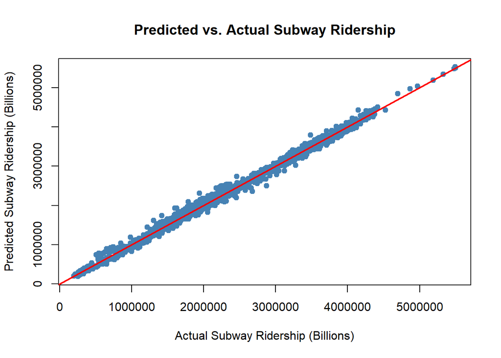

```r
options(scipen = 999)
actual <- df$`Subways: Total Estimated Ridership`
predicted <- predicted_full

plot(actual, predicted,
     xlab = "Actual Subway Ridership (Billions)",
     ylab = "Predicted Subway Ridership (Billions)",
     main = "Predicted vs. Actual Subway Ridership",
     pch = 19, col = "steelblue")
abline(a = 0, b = 1, col = "red", lwd = 2)
```

# Classification Question

## Updated - Can predict “low,” “average,” or “high” ridership by using classification statistical learning methods?

```r
### combining ridership
df$total_ridership <- (df$`Subways: Total Estimated Ridership`+
                         df$`Buses: Total Estimated Ridership`+
                         df$`LIRR: Total Estimated Ridership`+
                         df$`Metro-North: Total Estimated Ridership`+
                         df$`Staten Island Railway: Total Estimated Ridership`)
```

```r
quantiles <- quantile(df$total_ridership, probs = c(0.33, 0.66))

df$total_ridership_level <- cut(
  df$total_ridership,
  breaks = c(-Inf, quantiles[1], quantiles[2], Inf),
  labels = c("Low", "Average", "High")
)
```

```r
predictors <- c(
  "Subways: % of Comparable Pre-Pandemic Day",
  "Buses: % of Comparable Pre-Pandemic Day",
  "LIRR: % of Comparable Pre-Pandemic Day",
  "Metro-North: % of Comparable Pre-Pandemic Day",
  "Access-A-Ride: % of Comparable Pre-Pandemic Day",
  "Bridges and Tunnels: % of Comparable Pre-Pandemic Day",
  "Staten Island Railway: % of Comparable Pre-Pandemic Day"
)
```

## —- KNN —-

```r
df_knn <- na.omit(df[, c(predictors, "total_ridership_level")])
```

# Because KNN is distance-based it could be good to standardize predictors by scaling them, such as